# Assignment 5: Mixed models

Marton Kovacs / Zoltan Kekecs

# Introduction

This assignment is related to the previous lab assignment concerning perioperative pain and its psychological and hormonal predictors. Just like previously, you will set up linear model to predict postoperative pain after wisdom tooth surgery, but this time you will have to also take into account the fact that there is clustering in the data.

As a reminder, here is the protocol for data collection: “You have collected data from adults who were scheduled to undergo surgical extraction of the third mandibular molar (wisdom tooth surgery). Patients filled out a form in the waiting room before their surgery. The form contained questions about their sex, age, and weight, and psychological questionnaires assessing anxiety, pain catastrophizing, and mindfulness (see descriptions below). You also got blood samples and saliva samples from participants in the waiting room 5 minutes before their operations to determine the serum (a component of the blood) and salivary cortisol levels of participants. Participants were contacted 5 hours after the surgery to see how much pain they were experiencing. The **level of pain** at that moment was recorded using a numerical rating scale using a **scale of 0 to 10**, where 0 means “no pain” and 10 means “worst pain I can imagine”.

**The State Trait Anxiety Inventory:** T measures trait anxiety on a scale of 20 to 80, higher scores mean higher anxiety. Anxiety has been found in many studies to positively correlate with the level of pain experienced. This is **variable STAI_trait** in the dataset.

**The Pain Catastrophizing Scale** measures the extent of pain catastrophizing, which is characterized by a tendency to magnify the threat value of a pain stimulus and to feel helpless in the presence of pain, as well as by a relative inability to prevent or inhibit pain-related thoughts in anticipation of, during, or following a painful event. The total score on this scale ranges from 0 to 52, higher scores mean higher catastrophizing. Pain catastrophizing is one of the well-established predictors of clinical pain. This is **variable pain_cat** in the dataset.

**The Mindful Attention Awareness Scale (MAAS)** measures dispositional mindfulness, which may be described as a tendency to turn attention to present-moment experiences in an open, non-judgemental way. The MAAS total score ranges from 1 to 6 (an average of the item scores), with higher scores representing higher dispositional mindfulness. Trait mindfulness has been theorized to serve as a protective factor against pain, as the individual would be more objective about their pain experience and tend to associate less discomfort, despair, and hopelessness to the pain-related sensations. This is **variable mindfulness** in the dataset.

**Cortisol** is a stress hormone associated with acute and chronic stress. Cortisol levels are thought to be positively associated with pain experience. Cortisol can be **measured from both blood and the saliva**, although, serum cortisol is often regarded in medical research as more reliably related to stress (serum is a component of the blood plasma). These are **variables cortisol_serum**, and **cortisol_saliva** in the dataset.”

# Datasets

You will need two datasets for this assignment, datafile A and B. You can load them from the ‘data/’ folder.

# Task

First, fit a linear mixed model to estimate postoperative pain on datafile A. You should use the same fixed effect predictors as you used in your final model in the 3 assignment. (If you did not do that assignment, use the following predictors: age, sex, STAI, pain catastrophizing, mindfulness, and serum cortisol.) Importantly, the model has to account for the clustering of the data in different hospital sites. We have no reason to assume that the effects of the different predictors would be different in the different hospitals, so fit a random intercept model including the random intercept of hospital-ID. Once the model is built, note the model coefficients and the confidence intervals of the coefficients for all fixed effect predictors, and compare them to the ones obtained in the 3 assignment.

Also, compute the variance explained by the fixed effect predictors using marginal R<sup>2</sup>, and the variance explained by the fixed and random effect terms combined using conditional R<sup>2</sup>. Now use the model coefficients obtained on data file A to predict pain in datafile B.

**IMPORTANT:** Do not fit the regression models on data file B (don’t re-train your models), just use the regression equation you derived based on datafile A. These regression equations should be applied on the new data (datafile B), to predict pain.

Now compute the variance explained by the model on datafile B. You can do this by using the formula: **1 - (RSS / TSS) = R^2**. Compare this R<sup>2</sup> to the marginal and conditional R<sup>2</sup> values computed for the model on datafile A.

# What to report

Report the model coefficients and the confidence intervals of the coefficients for each fixed effect predictor obtained on data file A in a table.

Report the variance components for the fixed effects, the random intercept, and the residuals (from the model on data file A). Also report the marginal R<sup>2</sup> and the conditional R<sup>2</sup> squared obtained from the model on data file A, and the observed R<sup>2</sup> of this model for data file B.

# What to discuss

Compare the model coefficients and the confidence intervals observed in this assignment and the assignment for Lab 2 and discuss what you think the differences or similarities mean.

# Solution

## Read the data

Read the datasets used in this assignment. Pay attention to the extensions of the datafiles.

## Exploratory data analysis

Run an exploratory data analysis (EDA) to investigate the dataset.

Descriptive Statistics for Numeric Variables

| variable | mean | sd | min | q1 | median | q3 | max |
| --- | --- | --- | --- | --- | --- | --- | --- |
| STAI_trait | 39.66 | 4.91 | 24.00 | 36.00 | 40.00 | 43.00 | 52.00 |
| age | 39.99 | 4.96 | 28.00 | 37.00 | 40.00 | 43.00 | 51.00 |
| cortisol_saliva | 4.90 | 0.99 | 2.09 | 4.18 | 4.96 | 5.58 | 7.91 |
| cortisol_serum | 4.91 | 0.93 | 1.64 | 4.29 | 4.97 | 5.54 | 7.63 |
| mindfulness | 3.00 | 1.07 | 1.00 | 2.27 | 2.91 | 3.83 | 5.58 |
| pain | 4.84 | 1.63 | 0.00 | 4.00 | 5.00 | 6.00 | 10.00 |
| pain_cat | 29.98 | 4.53 | 17.00 | 28.00 | 30.00 | 33.00 | 41.00 |

```
##
## female   male   Male
##    103     96      1
```

```
##
##  hospital_1 hospital_10  hospital_2  hospital_3  hospital_4  hospital_5
##          20          20          20          20          20          20
##  hospital_6  hospital_7  hospital_8  hospital_9
##          20          20          20          20
```

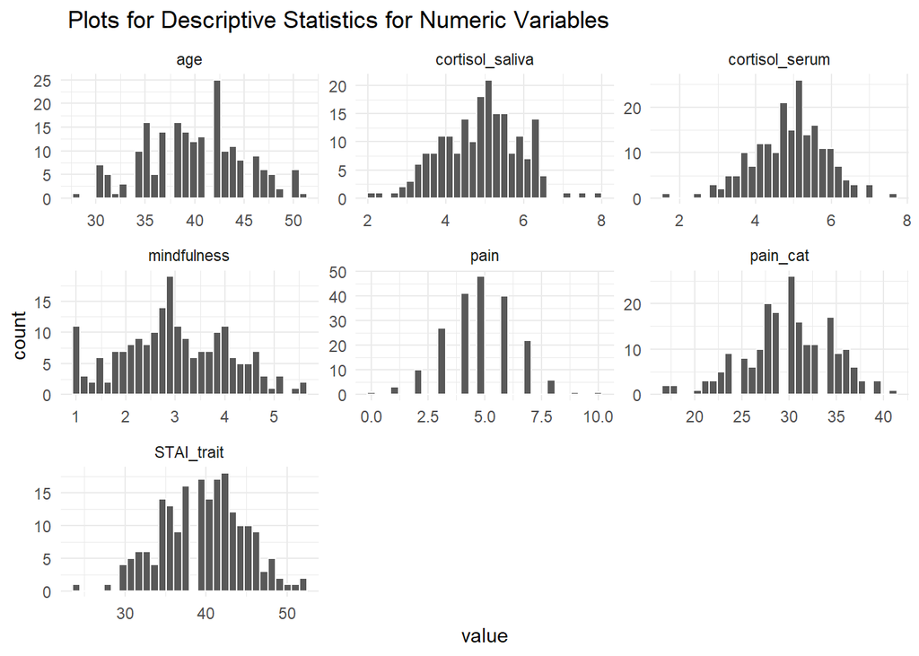

## Correct coding errors

The sex variable originally contained multiple categories representing “male,” which were consolidated into a single category to ensure consistency in coding. Additionally, any test scores that fell outside the permissible range were corrected to align with valid measurement boundaries.

## Mixed model and fixed model comparison

A linear mixed model with a random intercept for hospital site was fitted to predict postoperative pain from demographic, psychological, and hormonal predictors. The model included age, sex, STAI-score, pain-catastrophizing, mindfulness, and cortisol serum, with hospital as a random intercept.

### Mixed model interpretation

Full Fixed-Effect Estimates for the Mixed Model

| Predictor | Estimate | Std_Error | t_value | CI_lower | CI_upper |
| --- | --- | --- | --- | --- | --- |
| (Intercept) | 3.5023 | 1.3805 | 2.537 | 0.8415 | 6.2031 |
| Age | -0.0544 | 0.0198 | -2.745 | -0.0936 | -0.0162 |
| Sex (male) | 0.2975 | 0.1905 | 1.562 | -0.0696 | 0.6714 |
| STAI_trait | 0.0014 | 0.0239 | 0.060 | -0.0447 | 0.0477 |
| Pain catastrophizing | 0.0369 | 0.0286 | 1.288 | -0.0189 | 0.0922 |
| Mindfulness | -0.2624 | 0.1006 | -2.608 | -0.4578 | -0.0676 |
| Serum cortisol | 0.6100 | 0.1143 | 5.339 | 0.3889 | 0.8319 |

A linear mixed-effects model predicting postoperative pain was fitted with age, sex, STAI-score, pain catastrophizing, mindfulness, and cortisol serum as fixed effects, and a random intercept for hospital. The model showed significant effects for age, mindfulness, and cortisol serum. Specifically, older age predicted lower pain (β = –0.054, SE = 0.020, 95% CI [–0.094, –0.016]), greater mindfulness predicted lower pain (β = –0.262, SE = 0.101, 95% CI [–0.458, –0.068]), while higher cortisol serum predicted higher pain levels (β = 0.610, SE = 0.114, 95% CI [0.389, 0.832]). Sex, STAI_trait, and pain catastrophizing did not significantly predict pain.

The random intercept variance for hospitals was 0.313 (SD = 0.560), indicating substantial between-hospital variability.

The model’s marginal R² was 0.317, indicating that the fixed effects alone accounted for 31.7% of the variance in postoperative pain. The conditional R² was 0.436, meaning that the combination of fixed and random effects explained 43.6% of the variance. This difference suggests that hospital-level clustering contributed an additional roughly 12% to the explained variance.

### Comparison with fixed model

Fixed-Effect Estimates for Fixed Model

| Predictor | Estimate | Std_Error | t_value | p_value | CI_lower | CI_upper |
| --- | --- | --- | --- | --- | --- | --- |
| (Intercept) | 4.3260 | 1.4581 | 2.967 | 0.0034 | 1.4500 | 7.2019 |
| Age | -0.0738 | 0.0209 | -3.539 | 0.0005 | -0.1150 | -0.0327 |
| Sex (male) | 0.4231 | 0.2033 | 2.081 | 0.0387 | 0.0222 | 0.8241 |
| STAI_trait | 0.0040 | 0.0257 | 0.156 | 0.8759 | -0.0467 | 0.0547 |
| Pain catastrophizing | 0.0289 | 0.0306 | 0.945 | 0.3459 | -0.0314 | 0.0892 |
| Mindfulness | -0.2757 | 0.1077 | -2.560 | 0.0112 | -0.4880 | -0.0633 |
| Serum cortisol | 0.6242 | 0.1225 | 5.096 | 0.0000 | 0.3826 | 0.8658 |

The linear regression model predicting postoperative pain included age, sex, STAI-score, pain catastrophizing, mindfulness, and serum cortisol as predictors. Significant effects were found for age (β = –0.074, p < .001), sex (male higher pain; β = 0.423, p = .039), mindfulness (β = –0.276, p = .011), and cortisol serum (β = 0.624, p < .001). STAI-score and pain catastrophizing were not significant predictors. The model explained 35.7% of the variance (adjusted R² = .337).

## Prediction for Dataset B

The model trained on sample A explains 35% of the variance in the new sample (R²=0.3497686)